# Playing with RESOLVE/ECO

I downloaded the public Environmental COntext data release 1 (ECO DR1) catalog from the RESOLVE/ECO [website](http://resolve.astro.unc.edu/) (Moffett et al. 2015). The catalog contains archival data of a volume-limited sample of galaxies in the nearby universe. I had downloaded the catalog during the 227th AAS meeting, and on the plane ride back, I decided to make some pretty plots (and familiarize myself with the `pandas` and `seaborn` Python packages).

```python
import numpy as np
import seaborn as sns
import pandas as pd
import matplotlib.pyplot as plt
from itertools import izip

%matplotlib inline
```

```python
# The ECO header contains all of the column names (I've kept them consistent with the catalog)
df = pd.read_csv('eco_dr1.txt', delim_whitespace=True, skiprows=56, index_col=0,
                 names=['RAdeg', 'DEdeg', 'cz', 'rMag', 'logM', 'u-r', 'u-J', 'R50', 'R90', 'M', 'FM',
                        'Grp', 'Grpcz', 'FC', 'logMh', 'Den', 'FA', 'FHI', 'FG', 'CCr', 'CCb'])
```

## Color-magnitude diagrams

I plot contours of the ECO galaxy $(u-r)^e$ extinction-corrected colors versus their stellar masses. Early types and late types are separated and depicted in red and blue, although note that morphology is *not* a proxy for color. I've computed the kernel density estimation (KDE) of the underlying distribution and not the actual distribution of the galaxies in color-$M_\star$ space.

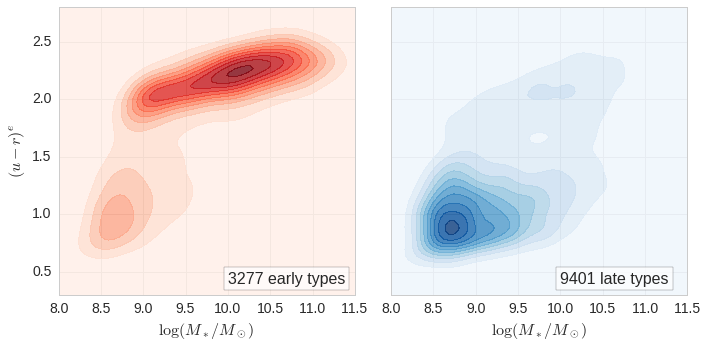

```python
sns.set_style('whitegrid')


# u-r color vs. log(mass) for early- and late-type galaxies
f, axes = plt.subplots(1, 2, figsize=(10, 5), sharey=True)

for ax, cmap, morphology in izip(axes, ['Reds', 'Blues'], ['E', 'L']):
    new_df = df[(df['M'] == morphology) & (df['u-r'] > -5)]

    sns.kdeplot(new_df['logM'], new_df['u-r'], shade=True, cmap=cmap, shade_lowest=True, alpha=0.8, ax=ax)

    ax.set_xlim(8.0, 11.5)
    ax.set_ylim(0.3, 2.8)

    m = 'early' if morphology == 'E' else 'late'

    ax.text(10.0, 0.4, '{} {} types'.format(len(new_df), m), fontsize=16,
            bbox=dict(facecolor='white', alpha=0.7))

    ax.set_xlabel(r'$\log(M_*/M_\odot)$', fontsize=16)
    ax.tick_params(labelsize=14)


axes[0].set_ylabel(r'$(u-r)^e$', fontsize=16)
axes[1].set_ylabel('')
plt.tight_layout()

plt.savefig('CMD_morphology.pdf', dpi=300)
```

## Other interesting trends between $M_\star$, normalized number density ($\Delta$), and $(u-r)^e$ color

Here I've plotted, for *central galaxies only*, $(u-r)^e$ versus stellar mass binned separately by the galaxy's host group mass, $\log M_h/M_\odot$.

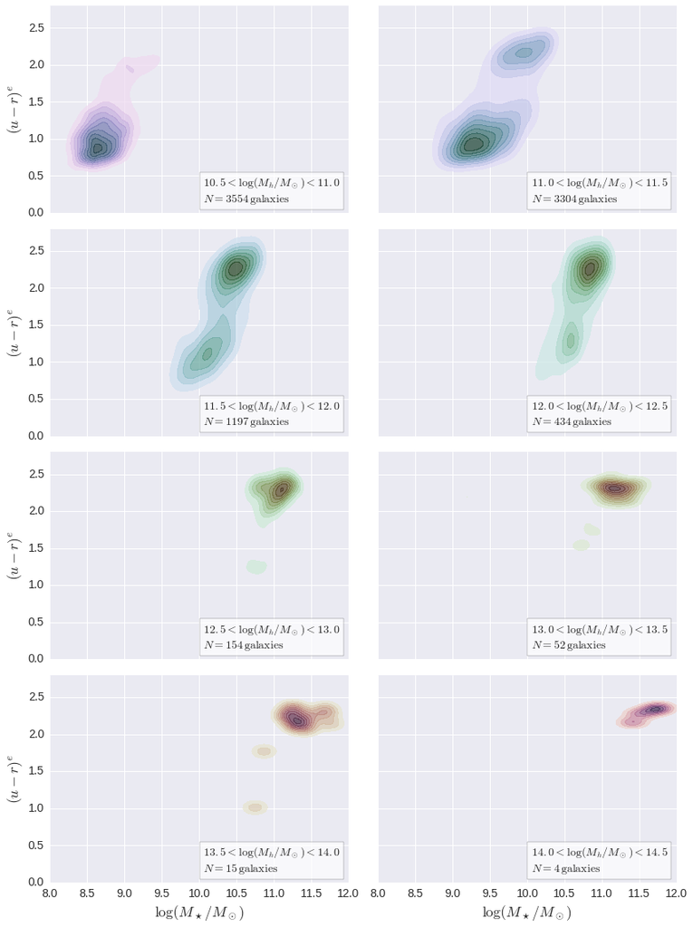

```python
sns.set_style('darkgrid')

# color versus stellar mass in bins of group mass -- centrals
f, axes = plt.subplots(4, 2, figsize=(12, 16), sharex=True, sharey=True)

# plots
for ax, s in izip(axes.flat, range(8)):
    min_Mh = 10.5 + 0.5 * s
    max_Mh = min_Mh + 0.5

    cmap = sns.cubehelix_palette(start=(7 - s) / 3., light=1, as_cmap=True)

    df_slice = df[(df['logMh'] > min_Mh) & (df['logMh'] < max_Mh) & (df['u-r'] > -5)]

    centrals = df_slice[df_slice['FC'] == 1]

    # kernel density estimate
    sns.kdeplot(centrals['logM'], centrals['u-r'], shade=True, cmap=cmap, shade_lowest=False, alpha=0.7, ax=ax)

    ax.set_xlim(8.0, 12.0)
    ax.set_ylim(0.0, 2.8)

    ax.text(10.05, 0.15, r'${} < \log(M_h/M_\odot) < {}$'.format(min_Mh, max_Mh) + '\n' + r'$N = {} \, \rm galaxies$'.format(len(centrals)),
            fontsize=14, bbox=dict(facecolor='white', alpha=0.7))

    if s >= 6:
        ax.set_xlabel(r'$\log(M_\star/M_\odot)$', fontsize=18)
    else:
        ax.set_xlabel('')

    if s % 2 == 0:
        ax.set_ylabel(r'$(u-r)^e$', fontsize=18)
    else:
        ax.set_ylabel('')

    ax.tick_params(labelsize=14)

plt.tight_layout()
plt.savefig('CMD_centrals.pdf', dpi=300)
```

Here I've plotted the same as above, but now for **satellite galaxies** in the ECO catalog.

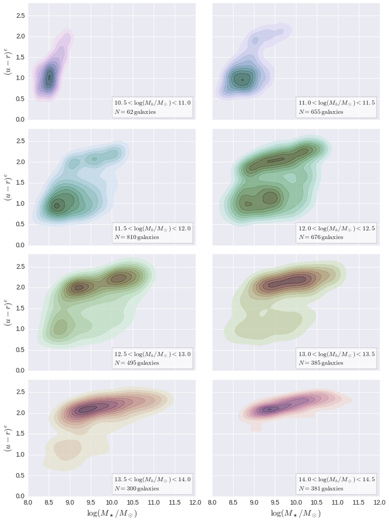

```python
# color versus stellar mass in bins of group mass -- satellite galaxies
f, axes = plt.subplots(4, 2, figsize=(12, 16), sharex=True, sharey=True)

# plots
for ax, s in izip(axes.flat, range(8)):
    min_Mh = 10.5 + 0.5 * s
    max_Mh = min_Mh + 0.5

    cmap = sns.cubehelix_palette(start=(7 - s) / 3., light=1, as_cmap=True)

    df_slice = df[(df['logMh'] > min_Mh) & (df['logMh'] < max_Mh) & (df['u-r'] > -5)]

    satellites = df_slice[df_slice['FC'] == 0]

    # kernel density estimate
    sns.kdeplot(satellites['logM'], satellites['u-r'], shade=True, cmap=cmap, shade_lowest=False, alpha=0.7, ax=ax)

    ax.set_xlim(8.0, 12.0)
    ax.set_ylim(0.0, 2.8)

    ax.text(10.05, 0.15, r'${} < \log(M_h/M_\odot) < {}$'.format(min_Mh, max_Mh) + '\n' + r'$N = {} \, \rm galaxies$'.format(len(satellites)),
            fontsize=14, bbox=dict(facecolor='white', alpha=0.7))

    if s >= 6:
        ax.set_xlabel(r'$\log(M_\star/M_\odot)$', fontsize=18)
    else:
        ax.set_xlabel('')

    if s % 2 == 0:
        ax.set_ylabel(r'$(u-r)^e$', fontsize=18)
    else:
        ax.set_ylabel('')

    ax.tick_params(labelsize=14)

plt.tight_layout()
plt.savefig('CMD_satellites.pdf', dpi=300)
```

In the next figure, I've plotted the $(u-r)^e$ color against density, separated into bins of stellar mass.

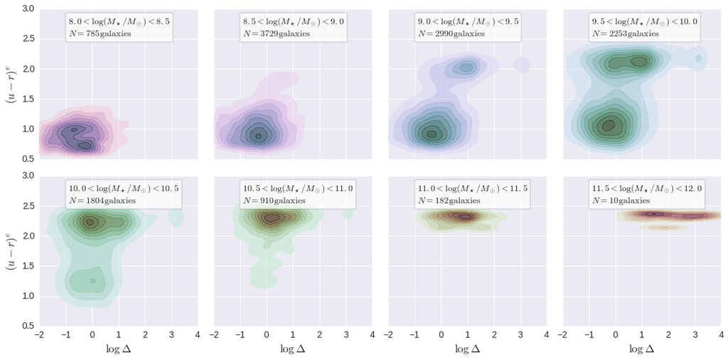

```python
# color versus normalized galaxy density, in bins of stellar mass
f, axes = plt.subplots(2, 4, figsize=(16, 8), sharex=True, sharey=True)

# plots
for ax, s in izip(axes.flat, range(8)):
    min_M = 8.0 + 0.5 * s
    max_M = min_M + 0.5

    cmap = sns.cubehelix_palette(start=(8 - s) / 3., light=1, as_cmap=True)

    dfx = df[df['Den'] > 0]

    df_slice = dfx[(dfx['logM'] > min_M) & (dfx['logM'] < max_M) & (dfx['u-r'] > -5)]

    # kernel density estimate
    sns.kdeplot(np.log(df_slice['Den']), df_slice['u-r'], shade=True, cmap=cmap, shade_lowest=False, alpha=0.7, ax=ax)

    ax.set_xlim(-2.0, 4.0)
    ax.set_ylim(0.5, 3.0)

    ax.text(-0.9, 2.55, r'${} < \log(M_\star/M_\odot) < {}$'.format(min_M, max_M) + '\n' +r'$N = {} \rm\, galaxies$'.format(len(df_slice)),
            fontsize=14, bbox=dict(facecolor='white', alpha=0.7))

    if s >= 4:
        ax.set_xlabel(r'$\log\, \Delta$', fontsize=18)
    else:
        ax.set_xlabel('')

    if s % 4 == 0:
        ax.set_ylabel(r'$(u-r)^e$', fontsize=18)
    else:
        ax.set_ylabel('')

    ax.tick_params(labelsize=14)

plt.tight_layout()
plt.savefig('color_vs_density_stellarmass_binned.pdf', dpi=300)
```

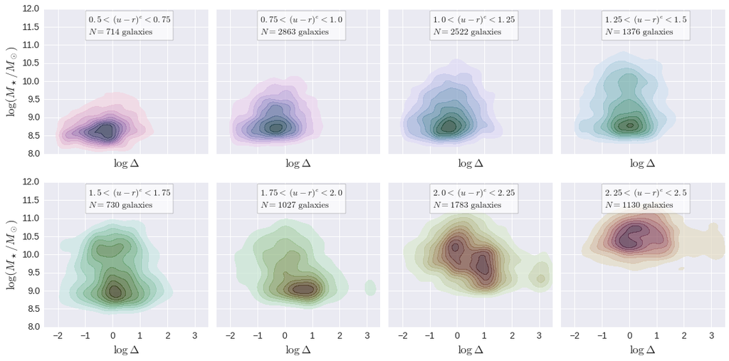

```python
# stellar mass versus normalized galaxy density, in bins of color
f, axes = plt.subplots(2, 4, figsize=(16, 8), sharex=True, sharey=True)


# plots
for ax, s in izip(axes.flat, range(8)):
    min_umr = 0.5 + 0.25 * s
    max_umr = min_umr + 0.25

    cmap = sns.cubehelix_palette(start=(8 - s) / 3., light=1, as_cmap=True)

    dfx = df[np.logical_and(df['Den'] > 0, df['u-r'] > -5)]

    df_slice = dfx[np.logical_and(dfx['u-r'] > min_umr, dfx['u-r'] < max_umr)]

    # kernel density estimate
    sns.kdeplot(np.log(df_slice['Den']), df_slice['logM'], shade=True, cmap=cmap, shade_lowest=False, alpha=0.7, ax=ax)

    ax.set_xlim(-2.5, 3.5)
    ax.set_ylim(8., 12.)

    ax.text(-0.9, 11.3, r'${} < \,(u-r)^e < {}$'.format(min_umr, max_umr) + '\n' +r'$N = {} \ \rm galaxies$'.format(len(df_slice)),
            fontsize=14, bbox=dict(facecolor='white', alpha=0.7))


    ax.set_xlabel(r'$\log\, \Delta$', fontsize = 18)

    if s % 4 == 0:
        ax.set_ylabel(r'$\log(M_\star/M_\odot)$', fontsize = 18)
    else:
        ax.set_ylabel('')

    ax.tick_params(labelsize=14)

plt.tight_layout()
plt.savefig('logM_vs_density_color_binned_2.pdf', dpi = 300)
```